# Bevezetés a gépi tanulásba

Vakhal Péter

2024-09-19

# Adatok betöltése

```r
adat<-read.csv(url("https://raw.githubusercontent.com/pvakhal/HUNREN/main/data.csv"), sep=",", dec=".")
```

Helyes adattípusok kialakítása

```r
library(dplyr)
adat<-type.convert(adat)
adat<-adat %>%
  mutate_if(is.integer, as.factor)
adat$tanarok_szama<-as.numeric(adat$tanarok_szama)
adat$tanarok_szama_telephelyen<-as.numeric(adat$tanarok_szama_telephelyen)
adat$diak_osszletszam<-as.numeric(adat$diak_osszletszam)
adat$diak_osszletszama_telephelyen<-as.numeric(adat$diak_osszletszama_telephelyen)
```

# Csomagok betöltése

```r
library(MASS)
```

```r
library(ggplot2)
library(klaR)
library(cluster)
library(factoextra)
library(class)
library(e1071)
library(glmnet)
```

Az adatok az Oktatási Hivatal 2019-es országos kompetenciafelméréseinek részeredményeit tartalmazza. Az adatbázis korlátozottan nyilvános, jelen oktatási kurzus keretében használható, egyéb esetben az adatgazda engedélye szükséges (a mindenkori Oktatási Hivatal). A A változók jelentését tartalmazó fájl külön kerül bemutatásra.

# Lineáris diszkriminancia elemzés (LDA)

A lineáris diszkriminancia elemzés célja, hogy egy már létező kategóriarendszer lehetséges besorolási szabályaira becslést adjunk úgy, hogy későbbiekben nem kategorizált egyedeket be lehessen sorolni. A modellt az 1920-as években dolgozták ki, ezzel az egyik legelső gépi tanulási algoritmusnak számít. Mivel a csoportbasorolások eleve adottak, így a módszer a felügyelt tanuló algoritmusok közé tartozik.

Az eljárás már két kategória esetén is elvégezhető, de igazán a $k>2$ esetben mutatkozik meg az ereje.

Legyen *j* csoport egy populációban: $\Pi_1, \Pi_2, \dots, \Pi_3$. Feladatunk eldönteni egy új *x* megfigyelésről a birtokunkban lévő ismert adatok alapján, hogy legnagyobb eséllyel mely csoportba tartozhat. A *diszkrimináló szabály* egy olyan szeparáció, amely a teret *j* darab altérre osztja ($R_j$) és amelyre igaz, hogy $x \in R_j$. Célfüggvényünk, hogy a klasszifikációs hibát minimalizáljuk.

Jelölje $\Pi_j$ egy tetszőleges változó sűrűségfüggvényét $f_j(x)$. A *maximális diszkrimináló szabályt* akkor kapjuk, ha *x*-et be tudjuk sorolni $\Pi_j$ kategóriába úgy, hogy az oda tartozás likelihood értékét maximalizáljuk, azaz $L_j(x)=f_j(x)=\max_i f_i(x)$.

Formailag az $R_j$ szeparált altér a következő:

$$R_j=\{x:L_j(x)>L_i(x) \quad \forall i \neq j \}$$

Azáltal, hogy egy elemet egy kategóriába besorolunk hibát véthetünk. Az egyszerűség kedvéért legyen két kategóriánk. Ekkor annak kockázata (“risk”), hogy egy elemet félreklasszifikálunk, a következő:

$$p_{21}=P(X \in R_2 | \Pi_1) = \int_{R_2} f_1(x)dx$$

A $p_{12}$ besorolási hiba valószínűsége a fenti analógiájára megadható. A klasszifikációs hibának költsége van, ami a következő: $C(i|j)$, ha egy $\Pi_i$ populációhoz tartozó elem az $R_j$ altérbe lett sorolva.

A következő költségmátrix ennek implikációja:

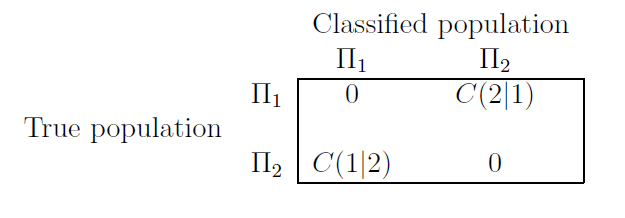

Most tegyük fel, hogy létezik $\pi_i$ apriori besorolási valószínűség (mielőtt még bármilyen információt tudnánk az egyedről) arra vonatkozóan, hogy egy tetszőlegesen kiválasztott $x_i$ elem a $\Pi_i$ csoportba tartozik. Ez implikálja a következő költségfüggvényt (*“Expected cost of misclassification”*) két kategóriás esetben:

$$ECM=C(2|1)p_{21}\pi_1+C(1|2)p_{12}\pi_2$$

Ez egyben a célfüggvényünk is, amit minimalizálni szeretnénk. Két kategória esetén a diszkrimináló függvény a következő:

Az egyszerűség kedvéért most feltételezzük, hogy a prior valószínűségek azonosak, továbbá hogy két kategória esetén mindkét eloszlás normális.

Ekkor annak a likelihood függvénye, hogy $x \in \Pi_i$ a következő:

$$L_i(x)=2(\pi \sigma_i^2)^{-1/2} \text{exp} \left\{ -1/2\times (\frac
{x_i-\mu_i} {\sigma_i})\right\}$$

Vagyis *x* $\Pi_1$-be lesz sorolva, ha $L_1(x) \geq L_2(x)$.

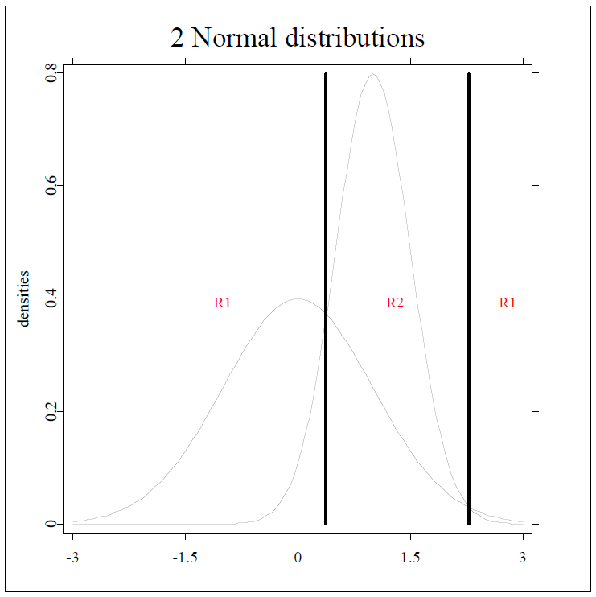

A probléma leegyszerűsödik, hogy a varianciákat azonosnak tételezzük fel:

$$x \to \Pi_1 \quad if \quad x \in R_1=\{x:x \leq 1/2(\mu_1+\mu_2)\} \\
x \to \Pi_2 \quad if \quad x \in R_2=\{x:x > 1/2(\mu_1+\mu_2)\}$$

A gyakorlatban ezt sokszor feltételezzük, és teszteljük is homogenitási vizsgálatokkal, ugyanakkor ez a feltétel csak ritkán teljesül. Szintén ritkán teljesül a normalitási feltétel is. Ezeket a próbákat itt most nem részletezzük, de alkalmazzuk őket.

# A kutatási kérdés rövid bemutatása

Az adatbázis **matek_8** elnevezési változója tartalmazza, hogy a diákok által elért matematika pontszám mely kvartilisbe esik:

```r
table(adat$matek_8)
```

```
##
##     1     2     3     4
## 18139 18137 18137 18136
```

Vizsgáljuk meg, hogy vajon mi befolyásolhatja a különböző csoportokba való tartozás esélyét! Használjuk a következő változókat (nincs mögötte tudományos érv):

- teltip7_th: településtipus, telephely
- t28: tanuló édesanyjának/nevelőanyjának legmagasabb iskolai végzettsége
- t29: tanuló édesapjának/nevelőapjának legmagasabb iskolai végzettsége
- t36: tanuló családjában a könyvek száma
- t5_a: tanuló osztályt ismételt: ált. Isk. 1-4. évf.
- t39: tanuló családja más családokkal összehasonlítva mennyire él jól
- t40b: tanuló családjában: a család megbeszéli az iskolában történteket
- t40c: tanuló családjában: a család beszélget arról, amit a tanuló éppen olvas
- t41: tanuló szülei az elmúlt években milyen gyakran mentek szülői értekezletre
- t48: tanuló szerint a környéken élő családok milyen körülmények között élnek
- t55_a: tanuló jár különórákra, magánórákra az iskolán kívül: matematika
- csh_index: tanuló standard családiháttér-indexe
- sex: tanuló neme
- hhh: tanuló halmozottan hátrányos helyzetű-e

Csak egy folytonos változónk van, vizsgáljuk meg a normalitását.

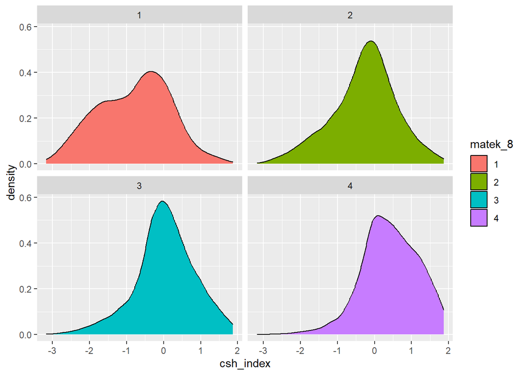

```r
ggplot(data=adat, aes(x=csh_index, group=matek_8, fill=matek_8)) + geom_density(adjust=1.5) +
facet_wrap(~matek_8)
```

Látható, hogy a legjobb teljesítményt nyújtó csoportban a családi háttér is messze a legjobb, sőt esetükben szinte kizárt az, hogy rossz csh indexe legyen a diáknak.

Vizsgáljuk meg a családi háttér index kiugró értékeit is (ha vannak):

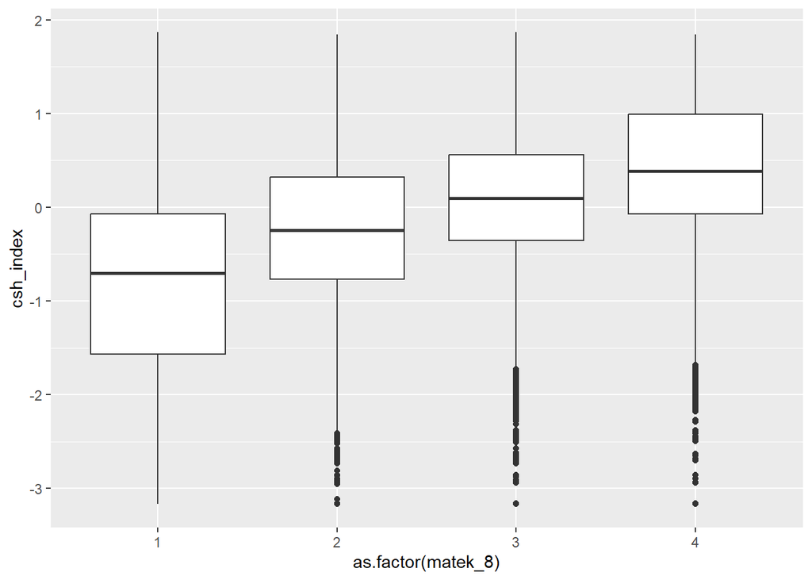

```r
ggplot(data=adat, aes(x=as.factor(matek_8), y=csh_index)) + geom_boxplot()
```

Az első kategóriában nincsenek kiugró értéket, ugyanakkor minél feljebb lépünk a matematika eredményekben annál ritkábbnak számít, ha a családi háttér rossz, ezért ők kiugró értéknek számítanak. Kezelhetjük őket logritmizálással, de nem muszáj, ők jó eséllyel félre lesznek klasszifikálva.

## Modellépítés

Építsük meg a modellünket:

```r
lda_model<-lda(matek_8~teltip7_th+t28+t29+csh_index+sex+hhh+t36+t5a+t39+t40b+t40c+t41+t48+t55a, data=adat)
```

Vizsgáljuk meg a modell objektumunkat:

```r
lda_model$prior
```

```
##         1         2         3         4
## 0.2500241 0.2499966 0.2499966 0.2499828
```

Látható, hogy a prior valószínűségek azonosak voltak, ami nem meglepő, mivel a kvartilisek elemszáma törvényszerűen azonos. A prior valószínűségek mindig a relatív gyakoriságokból számolódnak, nem érdemes azonban úgy hagyni őket, mivel a prior értékek nagyban befolyásolják a posterior becslést (a bayes-tétel miatt). Általánosságban az a legjobb, ha azonosnak feltételezzük a priorokat, ezzel adjuk a legkevesebb torzítást a modellnek.

```r
lda_model$svd
```

```
## [1] 88.88119 27.60440  8.24026
```

Az SVD felbontás eredményei, amit úgy értelmezhetünk, mint a sajátértékeket egy főkomponens elemzésben. Megmutatják, hogy a modellek a variancia mekkora részét magyarázzák:

```r
lda_model$svd^2 / sum(lda_model$svd^2)
```

```
## [1] 0.904933971 0.087287831 0.007778198
```

Kérjük le a modell outputját:

```r
lda_model
```

```
## Call:
## lda(matek_8 ~ teltip7_th + t28 + t29 + csh_index + sex + hhh +
##     t36 + t5a + t39 + t40b + t40c + t41 + t48 + t55a, data = adat)
##
## Prior probabilities of groups:
##         1         2         3         4
## 0.2500241 0.2499966 0.2499966 0.2499828
##
## Group means:
##   teltip7_th2 teltip7_th3 teltip7_th4 teltip7_th5 teltip7_th6 teltip7_th7
## 1   0.1269089   0.3920282  0.03715751   0.1775732   0.1404157  0.05149126
## 2   0.1687159   0.3910239  0.03004907   0.1489772   0.1145724  0.03699620
## 3   0.1903843   0.3652203  0.02833986   0.1361306   0.1011193  0.03054529
## 4   0.2146008   0.3625386  0.02486767   0.1001323   0.0733348  0.02172475
##         t282       t283      t284      t285       t286       t287       t292
## 1 0.28755720 0.07894592 0.2532664 0.2362313 0.06951872 0.02083908 0.25481008
## 2 0.14633071 0.06489497 0.2602966 0.3355571 0.13050670 0.04603848 0.13006561
## 3 0.08116006 0.04901582 0.2223631 0.3702928 0.19159729 0.07956112 0.06842366
## 4 0.03368990 0.02519850 0.1306242 0.3686590 0.27718350 0.16288046 0.03346934
##         t293      t294      t295       t296       t297   csh_index      sex1
## 1 0.07492144 0.4246100 0.1445504 0.03809471 0.02376096 -0.79906331 0.5153537
## 2 0.05783757 0.4417489 0.2410542 0.07184209 0.04543199 -0.28155268 0.4986492
## 3 0.04217897 0.4028230 0.2919446 0.10564040 0.08336550  0.03588956 0.4859128
## 4 0.02492281 0.2907477 0.3163322 0.17093075 0.16144685  0.41534257 0.4465704
##         hhh1       t362      t363       t364       t365       t366       t367
## 1 0.17669111 0.19824687 0.1958212 0.09807597 0.06477755 0.03076245 0.02188654
## 2 0.06665932 0.18205877 0.2628880 0.14087225 0.09759056 0.05656944 0.03820919
## 3 0.04460495 0.14533826 0.2884159 0.17957766 0.12521365 0.08297954 0.05171748
## 4 0.01268196 0.09616233 0.2523710 0.18598368 0.17958756 0.12880459 0.09202691
##          t5a2         t5a3       t392      t393      t394       t395      t40b1
## 1 0.062627488 0.0047962953 0.04404873 0.7668008 0.1338001 0.03627543 0.03842549
## 2 0.018084578 0.0015989414 0.03170315 0.7721784 0.1555935 0.02993880 0.02679605
## 3 0.008821746 0.0007719027 0.02199923 0.7597728 0.1831615 0.02911176 0.02210950
## 4 0.004466255 0.0006065285 0.01626599 0.6785399 0.2641707 0.03743935 0.02045655
##        t40b2     t40b3     t40b4     t40c1     t40c2     t40c3      t40c4
## 1 0.09123987 0.1405811 0.6795854 0.3759854 0.2714593 0.1856221 0.10380947
## 2 0.06588741 0.1333738 0.7325908 0.3441032 0.3408502 0.1737884 0.08882395
## 3 0.05149694 0.1242763 0.7603793 0.3588796 0.3269008 0.1817280 0.08182169
## 4 0.04912880 0.1321681 0.7567270 0.3402073 0.3200265 0.2084804 0.08144023
##         t412       t413      t414       t482      t483      t484        t485
```

[output cut: 50 more lines]

```
## t40c2        0.031594154 -0.38505696  0.714778249
## t40c3       -0.051536704  0.20261834  0.252392070
## t40c4       -0.240013550  0.07986156  0.324694116
## t412         0.006665914 -0.27893455 -0.267722809
## t413         0.129478583 -0.48166840  0.243945581
## t414         0.385596672 -0.39021490 -0.157683847
## t482         0.082328555 -0.26299944  0.745676046
## t483         0.079719812 -0.25995376  0.530265742
## t484        -0.020349159 -0.15422740  0.101931760
## t485        -0.133492348 -0.37863969  0.096365614
## t55a1       -0.631647642 -0.93028700  0.403164407
##
## Proportion of trace:
##    LD1    LD2    LD3
## 0.9049 0.0873 0.0078
```

Új információ a csoportátlagok a bevont változók szerint, inkább informatív tartalmat hordoz.

A koefficiensek azonban rendkívül fontosak! Úgy értelmezhetők, mint a béták egy regresszió esetén, vagyis értelmezhetővé teszik a modellt. A besorolás is e szerint végzendő el, mégpedig úgy, hogy végigszorozzuk az ismeretlen besorolású egyed értékeit és abbe a csoportba soroljuk, amelyiknek a legnagyobb az értéke. Ezt szerencsére nem kell kézzel elvégezni, az R megoldja magától.

A modell teszteléséhez válasszunk le egy véletlen mintát az adatbázisból, majd a maradékon tanítsuk be az algoritmust.

```r
minta_index<-sample(c(1:nrow(adat)), 1000) # mintába kerülők sorszáma

train<-adat[setdiff(c(1:nrow(adat)), minta_index),] # tanuló adatbázis
test<-adat[minta_index,] # teszt adatbázis

lda_model<-lda(matek_8~teltip7_th+t28+t29+csh_index+sex+hhh+t36+t5a+t39+t40b+t40c+t41+t48+t55a, data=train)

lda_test<-predict(lda_model, test)$class

table(test$matek_8, lda_test)
```

```
##    lda_test
##       1   2   3   4
##   1 121  65  51  27
##   2  58  91  46  47
##   3  33  57  60  82
##   4  10  42  78 132
```

```r
sum(diag(table(test$matek_8, lda_test)))/sum(table(test$matek_8, lda_test))
```

```
## [1] 0.404
```

## Kvadratikus diszkriminancia elemzés

A lineáris diszkriminancia elemzés azt feltételezte, hogy a döntési határok lineárisak, ami eléggé kemény megkötés. A kvadratikus modell ezt a feltételt nem teszi fel, ahogy nincs feltételezés az azonos varianciákra és a normalitásra sem.

Mivel nincsenek előzetes feltevéseink, ezért a modellek paramétereit a mintából nyert becslésekkel helyettesítjük, továbbá a valószínűségeket logaritmizáljuk.

```r
qda(matek_8~teltip7_th+t28+t29+csh_index+sex+hhh+t36+t5a+t39+t40b+t40c+t41+t48+t55a, data=adat)
```

```
## Call:
## qda(matek_8 ~ teltip7_th + t28 + t29 + csh_index + sex + hhh +
##     t36 + t5a + t39 + t40b + t40c + t41 + t48 + t55a, data = adat)
##
## Prior probabilities of groups:
##         1         2         3         4
## 0.2500241 0.2499966 0.2499966 0.2499828
##
## Group means:
##   teltip7_th2 teltip7_th3 teltip7_th4 teltip7_th5 teltip7_th6 teltip7_th7
## 1   0.1269089   0.3920282  0.03715751   0.1775732   0.1404157  0.05149126
## 2   0.1687159   0.3910239  0.03004907   0.1489772   0.1145724  0.03699620
## 3   0.1903843   0.3652203  0.02833986   0.1361306   0.1011193  0.03054529
## 4   0.2146008   0.3625386  0.02486767   0.1001323   0.0733348  0.02172475
##         t282       t283      t284      t285       t286       t287       t292
## 1 0.28755720 0.07894592 0.2532664 0.2362313 0.06951872 0.02083908 0.25481008
## 2 0.14633071 0.06489497 0.2602966 0.3355571 0.13050670 0.04603848 0.13006561
## 3 0.08116006 0.04901582 0.2223631 0.3702928 0.19159729 0.07956112 0.06842366
## 4 0.03368990 0.02519850 0.1306242 0.3686590 0.27718350 0.16288046 0.03346934
##         t293      t294      t295       t296       t297   csh_index      sex1
## 1 0.07492144 0.4246100 0.1445504 0.03809471 0.02376096 -0.79906331 0.5153537
## 2 0.05783757 0.4417489 0.2410542 0.07184209 0.04543199 -0.28155268 0.4986492
## 3 0.04217897 0.4028230 0.2919446 0.10564040 0.08336550  0.03588956 0.4859128
## 4 0.02492281 0.2907477 0.3163322 0.17093075 0.16144685  0.41534257 0.4465704
##         hhh1       t362      t363       t364       t365       t366       t367
## 1 0.17669111 0.19824687 0.1958212 0.09807597 0.06477755 0.03076245 0.02188654
## 2 0.06665932 0.18205877 0.2628880 0.14087225 0.09759056 0.05656944 0.03820919
## 3 0.04460495 0.14533826 0.2884159 0.17957766 0.12521365 0.08297954 0.05171748
## 4 0.01268196 0.09616233 0.2523710 0.18598368 0.17958756 0.12880459 0.09202691
##          t5a2         t5a3       t392      t393      t394       t395      t40b1
## 1 0.062627488 0.0047962953 0.04404873 0.7668008 0.1338001 0.03627543 0.03842549
## 2 0.018084578 0.0015989414 0.03170315 0.7721784 0.1555935 0.02993880 0.02679605
## 3 0.008821746 0.0007719027 0.02199923 0.7597728 0.1831615 0.02911176 0.02210950
## 4 0.004466255 0.0006065285 0.01626599 0.6785399 0.2641707 0.03743935 0.02045655
##        t40b2     t40b3     t40b4     t40c1     t40c2     t40c3      t40c4
## 1 0.09123987 0.1405811 0.6795854 0.3759854 0.2714593 0.1856221 0.10380947
## 2 0.06588741 0.1333738 0.7325908 0.3441032 0.3408502 0.1737884 0.08882395
## 3 0.05149694 0.1242763 0.7603793 0.3588796 0.3269008 0.1817280 0.08182169
## 4 0.04912880 0.1321681 0.7567270 0.3402073 0.3200265 0.2084804 0.08144023
##         t412       t413      t414       t482      t483      t484        t485
## 1 0.14967749 0.16787033 0.6430895 0.06599041 0.7774960 0.1222780 0.010474668
## 2 0.08507471 0.13497271 0.7612064 0.04460495 0.8228483 0.1132492 0.008876882
## 3 0.05838893 0.10624690 0.8237856 0.03197883 0.8264873 0.1260407 0.009042289
## 4 0.03865240 0.09042788 0.8612704 0.02398544 0.8030437 0.1590207 0.010476401
##       t55a1
## 1 0.1217267
## 2 0.1439599
## 3 0.1237801
## 4 0.0903176
```

A nem lineáris szeparáció sajnos azzal jár, hogy a modell részben elveszti azt az interpretálhatóságot, amit az LDA tartalmazott (koefficiensek), így nincsenek egyenleteink.

Hasonlóan az előző példához, itt is végezzük el a predikciót.

```r
qda_model<-qda(matek_8~teltip7_th+t28+t29+csh_index+sex+hhh+t36+t5a+t39+t40b+t40c+t41+t48+t55a, data=train)

qda_test<-predict(qda_model, test)$class

table(test$matek_8, qda_test)
```

```
##    qda_test
##       1   2   3   4
##   1 112  35  23  94
##   2  59  34  29 120
##   3  33  20  28 151
##   4  14   9  13 226
```

```r
sum(diag(table(test$matek_8, qda_test)))/sum(table(test$matek_8, qda_test))
```

```
## [1] 0.4
```

# Szegmentációs algoritmusok

A klasszikus particionáló algoritmusok úgynevezett felügyelő nélkül tanuló eljárások, amelyek célja, hogy mintázatokat ismerjenek fel egy nem strukturált adathalmazban. Az algoritmus a lehető leghomogénabb csoportbesosorolást hozza létre két feltétel mellett:

1. Az egy szegmensbe tartozó elemek a lehető leghomogénebbek legyenek. A homogenitás többféleképpen is mérhető, de általában a szórás minimalizálásán alapulnak.
2. A különböző csoportok a lehető legjobban különbözzenek egymástól. Ez leggyakrabban a csoportsúlypontok távolságainak maximalizálását jelenti.

A homogenitás felfogható hasonlósági mértékként is, amely hasonlóságot a távolsággal szokás megadni (legtöbbször négyzetes euklideszi normát használva). Külön távolság metrikákat alkalmazunk a folytonos eloszlású adatokra (pl.: euklideszi), a diszkrét eloszlású adatokra (pl.: Jaccard), illetve a vegyes eloszlásúakra (pl.: Gower).

### A gower-féle távolságmetrika

Vegyes adattípusok (diszkrét és folytonos) közötti távolságmetrika. Legyen *i* és *j* két *p* dimenziós objektum. A kettő közötti gower-féle távolság a következő:

$$S_{ij}=\frac {\sum_{k=1}^pw_{ijk}s_{ijk}} {\sum_{k=1}^pw_{ijk}}$$

ahol,

$w_{ijk}$: nem negatív súly (összege 1) $s_{ijk}$: hasonlóság két objektum között a *k*-adik dimenzióban

Ha az két összehasonlított változó bináris vagy ordinális, akkor $s_{ijk}$ értéke 0 vagy 1, ha folytonos, akkor $s_{ijk}=1-\frac {|x_i-x_j|} {R_k}$, ahol $R_k$ a *k*-adik dimenzió terjedelme (csak normalizálási célokat szolgál). A végső távolságot az egyedi távolságok súlyozott átlaga adja meg, ahol a súly alapértelmezetten egyenletes.

## A k-közép eljárás

Az egyik legrégebben alkalmazott szegmentációs algoritmus. Hátránya, hogy előre meg kell adni, hogy mennyi particiót szeretnénk kialakítani.

Legyen $s_j$ a *j*-edik klaszter középpontja, azaz $s_j=|C_j|^{-1} \sum x_j, \quad \forall x_j \in C_j$. Legyen *WSS* a veszteségfüggvény, azaz
$$WSS_j=\sum ||x_j-s_j||_2^2$$

Célunk a fenti veszteségfüggvény minimalizálása. Az algoritmus a következő:

1. Vegyünk fel *k* darab klaszter tömegközéppontot egymástól távolabb véletlenszerűen.
2. Soroljuk be nulladik lépésben a megfigyeléseket a legközelebbi halmazba.
3. Újraszámoljuk a klaszter súlypontokat.
4. Újra átsoroljuk a megfigyeléseket.
5. A rendszer stabilizálódása után az algoritmus leáll.

Mivel 72 ezer megfigyelésünk van 69 dimenzióban ezért túlságosan nagy számítókapacitást igényelne minden hallgató klaszterezése, ezért a könnyebbség kedvéért szűkítsük le a mintát csupán 1 megyére (12-es kódszámú, a legkisebb).

```r
adat2<-adat[adat$megye_kodja==12,]
```

Számoljuk ki a Gower-féle távolságot!

```r
tav<-daisy(adat2[,-c(1,2,64)]) # nincs szükségünk az azonosítószámokra és a megyekódra sem
```

A klaszterszám meghatározása kvázi intuitív folyamat. Minél többet alakítunk ki, annál homogénebbek lesznek a csoportok. Léteznek algoritmusok amelyek segítenek a döntésben. Ezek alapja jellemzően az, hogy mekkora homogenitási többletet érünk el egy új szegmens felvételével. Az új klaszterek hozadéka szinte minden esetben csökkenő.

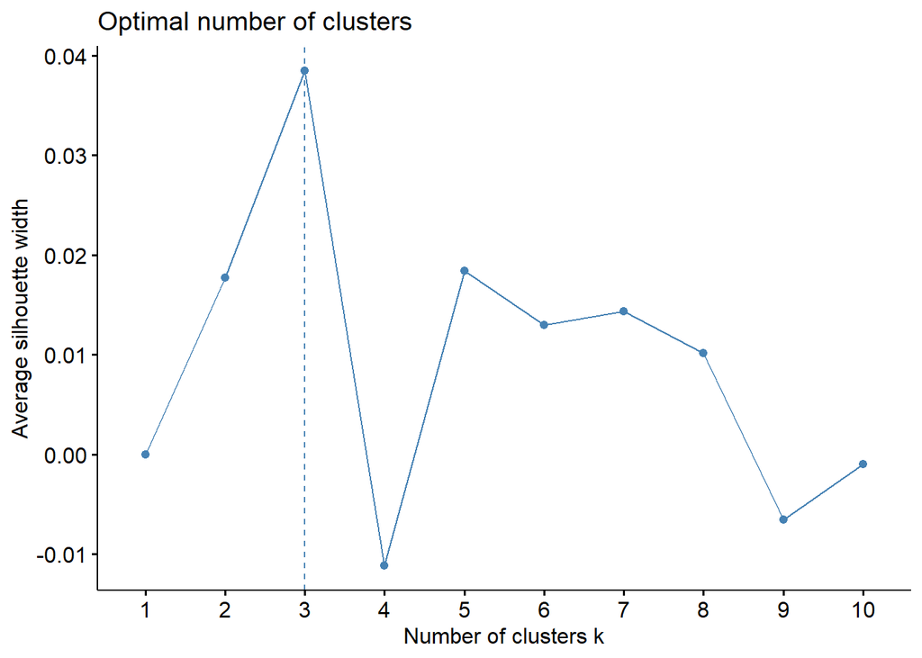

```r
fviz_nbclust(adat2, kmeans, method = "silhouette", diss=tav)
```

Az optimális klaszterszám a 3 vagy 5. A nagy minta miatt érdemes lehet az 5 klasztert választani.

```r
kkozep<-kmeans(tav, centers = 5)
kkozep$size # klaszterek elemszámai
```

```
## [1] 238 399 199 282 286
```

```r
adat2$kkozep<-kkozep$cluster # mentsük el a besorolásokat
```

Vizsgáljuk meg az eredményeket néhány szemszögből!

A matematika eredmények (sor) és a szegmensek (oszlop)

```r
table(adat2$matek_8, adat2$kkozep)
```

```
##
##       1   2   3   4   5
##   1 162 190  34  91  49
##   2  49 111  45  74  63
##   3  23  68  47  91  86
##   4   4  30  73  26  88
```

A fajlagos ráfordítás és a családi háttér index:

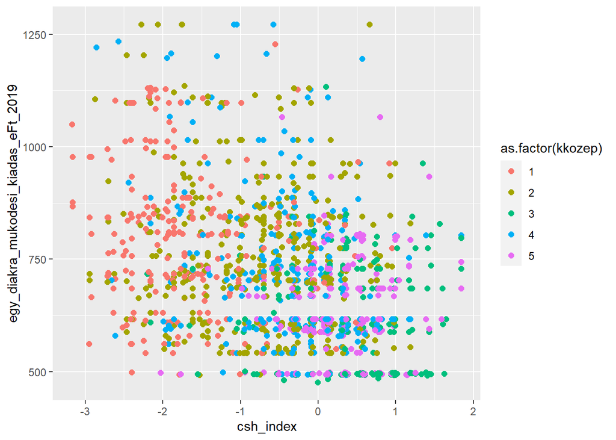

```r
ggplot(adat2, aes(x=csh_index, y=egy_diakra_mukodesi_kiadas_eFt_2019, colour=as.factor(kkozep))) + geom_point(size=2)
```

## k-NN algoritmus

Az algoritmus egy klasszifikációs eljárás, amely bármekkora csoportszámra képest becslést adni arra nézve, hogy egy egyed mely kategóriába tartozhat. Formális leírása:

$$P(y=c|x,D,K)=K^{-1}\sum I(y_i=c)$$

ahol,

c = egy osztály, ahol $c \in N$ x = attribútumok, magyarázó változók D = tengely, amin x értelmezett K = legközelebbi pontok száma I = indikátor függvény, amelynek értéke 1, ha az állítás igaz, egyébként 0.

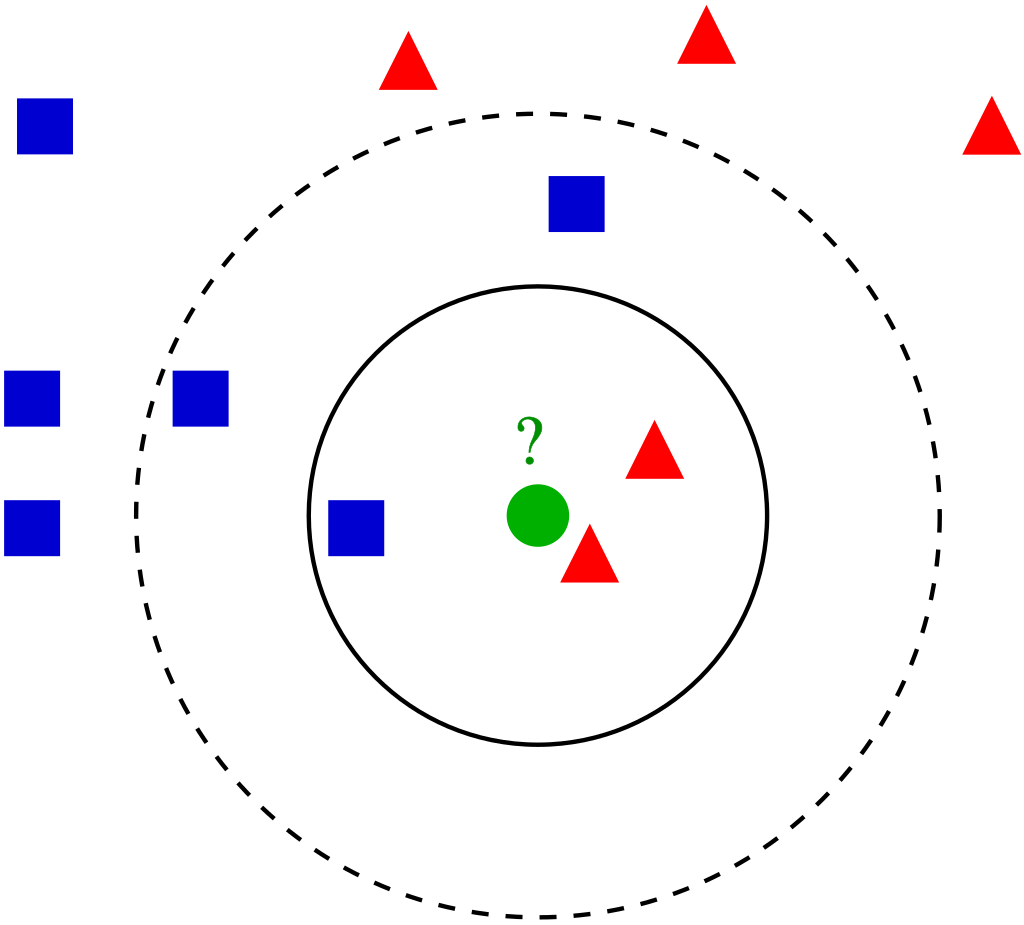

Végezzük el a kNN eljárást! Ez igényel némi adatelőkészítést.

1. a tanuló adathalmaz nem tartalmazhatja a célváltozót, ezt külön vektorban kell megadni majd (matek_8, 8. oszlop)
2. Értelemszerűen a teszt adatbázis sem tartalmazhatja.
3. Hasonlóan a k-közép módszerhez, itt is meg kell adni a szomszédsági számot előre, de ehhez nincs igazán segítség. Jelen esetben adjunk meg 3-at

```r
k_nn<-knn(train[,-c(1,2,8)], test[,-c(1,2,8)], cl=train$matek_8, k=3)
```

Vizsgáljuk meg az eredményeket:

```r
table(test$matek_8, k_nn)
```

```
##    k_nn
##       1   2   3   4
##   1 127  80  42  15
##   2  48  78  84  32
##   3  36  64  67  65
##   4  17  33  73 139
```

```r
sum(diag(table(test$matek_8, k_nn)))/sum(table(test$matek_8, k_nn))
```

```
## [1] 0.411
```

## Naív-Bayes osztályozó

Egy másik, nagyon egyszerű, de mégis hatékony osztályozó a Bayes klasszifikátor.

Legyenek egy tanuló halmazon előre definiált osztályok, illetve az osztályok által részhalmazokba tartozó attribútumok (features). Ekkor a feltételes valószínűségi eloszlás ismert: $p(x|y=c_k)$, amiből levezethető a Bayes-tétel alapján, hogy:

$$p(C_k|x)=\frac {p(C_k) p(x|C_k)} {p(x)}$$

A Bayes feltételes valószínűség számlálója a következő többdimenziós feltételes eloszlással egyenlő:

$$p(C_k)(p(x|C_k)=p(C_k, x_1, x_2, \dots, x_n)p(x_1|x_2, \dots, C_k)p(x_2,
\dots, x_n, C_k) \dots$$

Amiból az osztályba való tartozás a következőképpen becsülhető
$$\hat{y}=argmax_K \text{ }p(C_k) \prod_{n=1}^p p(x_i|C_k)$$

A modell minden osztályra becsül egy valószínűséget az *argmax* argumentum pedig kiválasztja belőle a legmagasabb értéket. A már korábban kialakított tanuló és tesztelő adatbázis segítségével végezzük el a becslést a matek_8 változóra.

```r
bayes<-naiveBayes(matek_8~.-1,-2, data=train)

table(test$matek_8, predict(bayes, test))
```

```
##
##       1   2   3   4
##   1 163  68  30   3
##   2  84  75  58  25
##   3  27  38  84  83
##   4   8  17  52 185
```

```r
sum(diag(table(test$matek_8, predict(bayes, test))))/sum(table(test$matek_8, predict(bayes, test)))
```

```
## [1] 0.507
```

# Változószelekciós, zsugorító eljárások

## Statisztikai tanulás néhány alapfogalma

Egy tanuló algoritmusnak általánosságban három komponense van:

1. Egy $x\in \mathbb{R}^n$ véletlen vektor generátor (*G*), amely független mintát vesz egy ismeretlen, de nem változó $F(x)$ valószínűségi eloszlásból.
2. Egy felügyelő (*S*), ami minden $x$ bemeneti adatra egy kimeneti $y$ output választ ad, egy szintén ismeretlen $F(y|x)$ feltételes eloszlás alapján.
3. Egy tanuló gép (*learning machine - LM*), amely egy $f(x, \alpha)$, $\alpha \in \Lambda$ függvényt illeszt, amely a legjobb becslést adja az *S* felügyelő válaszára.

A megfelelő függvény kiválasztása az $\ell$ tanuló adathalmaz alapján történik, amely elemei az $F(x,y)=F(x)F(x|y): (x_1,y_1),\dots,(x_{\ell},y_{\ell})$ alapján kerülnek kiválasztásra véletlen mintavétellel.

Annak érdekében, hogy a legjobb függvényt meg tudjuk találni a $S$ becslésére, az $L(y,f(x,\alpha))$ **veszteségfüggvényt** kell alapul vegyük, ami az $y$ ($S$ válasza) és az *LM* által adott $f(x,\alpha)$ becsült válasz közötti eltérés. Tekintsük a veszteség várható értékét, amit a *risk-függvény* mutat meg:

$$R(\alpha)=\int L(y, f(x,\alpha))dF(x,y)$$

Célunk egy olyan $f(x, \alpha_0)$ függvény megtalálása, ami minimalizálja $R(\alpha)$-t egy olyan szituációban, mikor $F(x,y)$ nem ismert, csak a tanulóhalmazra lehet támaszkodni.

Ahhoz, hogy a risk-függvényt minimalizálni tudjuk egy ismeretlen $F(z)$ valószínűségi mérték mellett, a következőt tehetjük:

A risk-függvényt, cseréljük le az úgynevezett *empirikus risk-függvényre*, amit a tanuló minta alapján hozunk létre:
$$R_e(\alpha)=\ell^{-1}\sum_{i=1}^{\ell}Q(z_i, \alpha)$$

Ezután $Q(z, \alpha_0)$ függvényt, ami az $R(\alpha)$ risk-függvényt minimalizálja, $Q(z, \alpha_{\ell})$ függvénnyel közelítjük, ami a tapasztalati risk-függvényt minimalizálja. Ezzel az elvvel igazából a korábban bemutatott regressziót és klasszifikációs algoritmust kapjuk vissza, vagyis ezek a “korabeli” módszerek is a gépi tanulás osztályába tartoznak.

Az ERM-elv azon a feltételezésen alapul, hogy $\ell/h>20$, vagyis a probléma bonyolultságához képest elegendő megfigyelés áll rendelkezésre. Ha $\ell/h$ értéke nagy, akkor $\mathcal{E}$ következésképp kicsi, azaz a tapasztalati risk-függvény értéke közel lesz a valós risk-függvény értékéhez, ami jó becslést biztosít. Ugyanakkor, ha $\ell/h<20$, akkor mindez nem garantált. Ahhoz, hogy a tanulási folyamat így is sikeres legyen, a VC dimenzió számát kontrollálni szükséges, vagyis a probléma bonyolultságát korlátozni kell. Egy $Q(z,\alpha), \alpha \in \Lambda$ valós függvényhalmaz VC dimenziója azon $z_1, \dots, z_h$ vektorok *h* maximális száma, amelyek a halmaz függvényei segítségével minden lehetséges módon ($2^h$) két osztályba sorolhatók. Az eljárás SRM néven vált ismertté.

Legyen a szokásos $Q(z,\alpha), \alpha \in \Lambda$ valós függvényhalmaz, majd ennek vegyik $S_k$ “nyesett” részhalmazait, azaz $S_k= \{Q(z, \alpha),\alpha \in \Lambda_k \}$ és $S_1 \subset S_2 \subset \cdots \subset C_n \cdots S_k$ halmaz elemei kielégítik a következő két feltételt:

1. Minden $S_k$ halmaz $h_k$ VC dimenziója véges, ezért az alábbi rendezés lehetséges: $h_1 \leq h_2 \leq \dots h_n\dots$.
2. A struktúra bármely $S_k$ eleme két dolgot tartalmazhat:

I. Teljesen korlátozott $Q(z,\alpha)$ függvényeket, azaz

$$0 \leq Q(z,\alpha) \leq B, \alpha \in \Lambda_k$$

VAGY

olyan fügvényeket, amelyekre teljesül a következő egyenlőtlenség (bármely p, $\tau_k$ párra):

$$\sup_{\alpha \in \Lambda_k} \frac {(\int Q^p(z,\alpha)dF(z))^{1/p}}
{\int Q(z,\alpha) dF(z)} <\tau_k, p>2$$

Ez az egyenlőtlenség a tanulási folyamat teljesítményét méri.

Amennyiben a fentiek teljesülnek, úgy a szerkezetet *elfogadható* struktúrának nevezzük. Az SRM a $z_1, \dots, z_{\ell}$ tanulómintán $Q(z, \alpha_{\ell}^k)$ függvényhalmazból “kiválasztja” azt a függvényt, ami minimalizálja az empirikus risk-függvényt $S_k$ halmazon. Az SRM-elv megteremti az átváltást az adott tanulóhalmazon végzett becslés minősége, valamint az approximációs függvény komplexitása között. Minél nagyobb az $S_n$ halmaz (minél komplexebb függvényeket tartalmaz), a tapasztalati risk minimuma úgy fög csökkenni, a becslés konfidencia intervalluma azonban szélesedni fog. Vagyis egyre nagyobb bizonytalanság mellett tudunk megoldani egyre komplexebb megoldásokat igénylő problémákat. A “trade-off” tehát itt az, hogy megtaláljuk az összhangot a két tulajdonság között.

## Változószelekciós eljárások

A változószelekciós eljárások az SRM elvét követik. A teljes modellből indulnak ki, de nem a változókat zárják ki, hanem a béta esztimátorok méretét csökkentik, annak árán, hogy így a modell ugyan torzít, de nincs jelentős információveszteség. Félút a drasztikus és a puha módszer között.

Csak *standardizált* változókon működik, ezért az interpretációnál nagyon vigyázzunk: ceteris paribus 1 szórásnyi változás a prediktorban **átlagosan** bétányi szórással jár együtt a függő változóban.

## Ridge regresszió

A módszer a következő módosítást hajtja végre a hagyományos OLS regresszión:
$$\hat{\beta}=(X'X+\lambda
I)^{-1}X'y$$

ahol, I: egy egységmátris $\lambda$: zsugorítási paraméter

Vegyük észre, hogy $\lambda I$ egy X’X **diagonálisát** változtatja meg $\lambda$ paraméterrel. Az algoritmus iteratív, azaz különböző $\lambda$ értékeket kell kipróbálnunk.

A módszer előbb a hagyományos OLS regresszió módszerével becslést ad $\beta$ értékére, majd ezeket az értékeket “zsugorítja” $\lambda$ paraméterrel. A cél, hogy a megváltozott $\beta$ értékek mellett minimalizáljuk az RSS értékét.
$$\hat{\beta}^{ridge}=argmin_{\beta}
\left\{\sum_{i=1}^N \left(y_i-\beta_0-\sum_{j=1}^p x_{ij}\beta_j
\right)^2+\lambda \sum_{j=1}^p \beta_j^2 \right\}$$

ahol, $\beta$: az OLS regresszió becslése

Vagyük észre, hogy a halmaz első tagja maga az OLS regresszió RSS értéke.

A fenti redge egyenletet másként is felírhatjuk optimumkereső függvényként is felírhatjuk:
$$\hat{\beta}^{ridge}=min_{\beta} \sum_{i=1}^N
\left(y_i-\beta_0-\sum_{j=1}^p x_{ij}\beta_j\right)^2, \\
\sum_{j=1}^p \beta_j^2 \leq t$$

*t* értékét előre meg kell határozni, bár inkább használatos az iteratív eljárás, amely során különböző *t*-ket próbálunk ki.

Megjegyzések az algoritmushoz: * A módszer regresszióként működik, ezért a függő változó az exponenciális eloszláscsalád tagjai közül kell származzon * A függő változót külön változóban tároljuk, ne az adathalmaz részeként. * A magyarázó változókat *mátrixként* tároljuk el, szintén külön

```r
matek_8<-as.numeric(adat$matek_8) # poisson eloszlást fogunk alkalmazni
ridge<-glmnet(y=matek_8, x=as.matrix(adat[,-c(1,2,8)]), family = "poisson", alpha = 0) # alpha=0 -> ridge regesszió
```

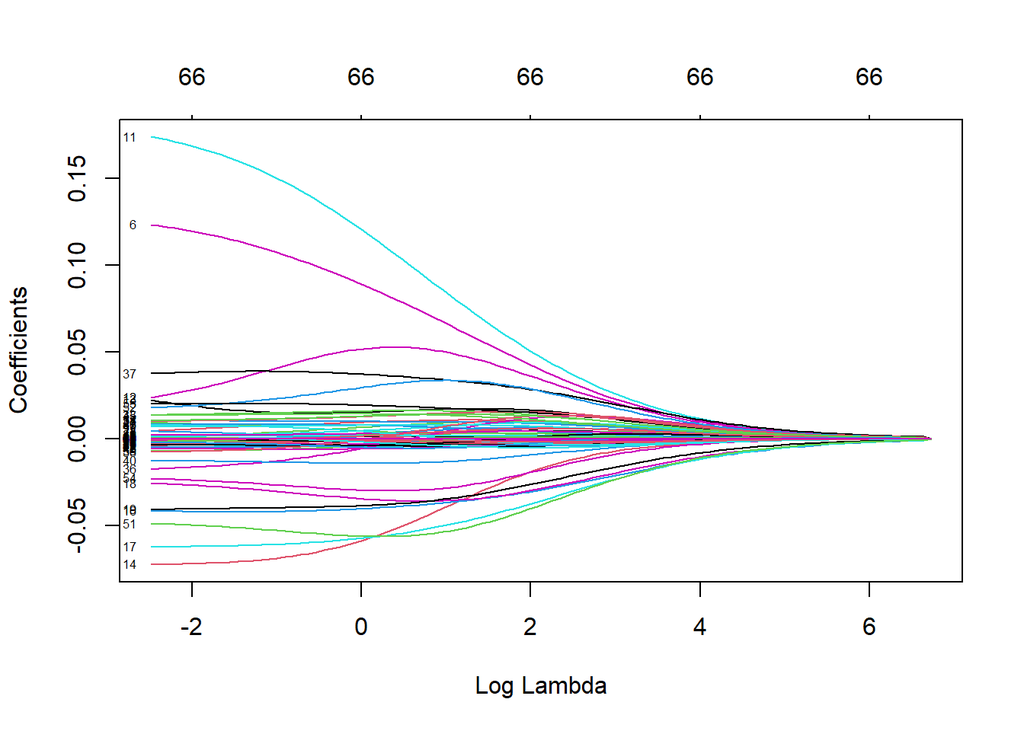

```r
# ábrázoljuk a béta esztimátorok értékét különböző lambdák mellett
plot(ridge, label = TRUE, xvar = "lambda")
```

Ahogy $\lambda \to +\infty$ úgy lesz egyra nagyobb a zsugorítás. Magas $\lambda$ értékeknél már mindegyik $\hat{\beta}$ értéke a nullához konvergál. Mivel az algoritmus standardizált adatokkal dolgozik, össze tudjuk hasonlítani a $\hat{\beta}$ értékeket. Minél nagyobb $|\hat{\beta}|$ értéke, a hozzá tartozó változó szorásának egységnyi növekedése átlagosan annál nagyobb szórásnövekedést jelent a függő változóban.

A LASSO módszer egy módosított ridge regresszió:
$$\hat{\beta}^{LASSO}=min_{\beta} \sum_{i=1}^N
\left(y_i-\beta_0-\sum_{j=1}^p x_{ij}\beta_j \right)^2 \\
\sum_{j=1}^N |\beta_j| \leq t$$

A programozási feladat a ridge módszerhez hasonlóan iteratív módon történik. Ha *t* értéke alacsony, akkor néhány $\hat{\beta}$ értéke nulla lehet, ezzel pedig a LASSO lényegében egy best subset szelekciót hajt végre. Ha $t_0 \geq \sum_{j=1}^N |\hat{\beta}^{OLS}|$, akkor a módszer az OLS eredményeit adja vissza. Ha viszont $t=t_0/2$, akkor a változók kb. fele elveszik.

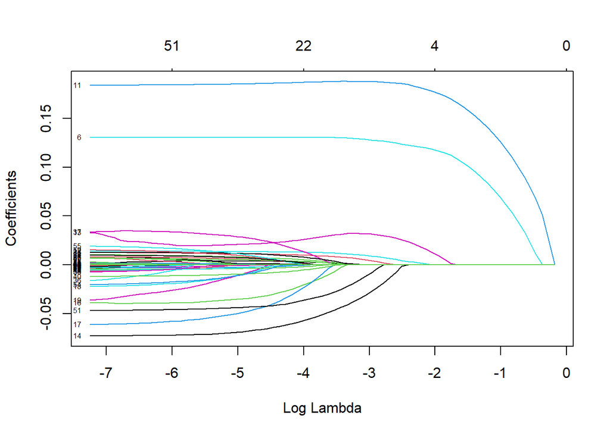

```r
lasso<-glmnet(y=as.numeric(matek_8), x=as.matrix(adat[,-c(1,2,8)]), family = "poisson", alpha = 1) # alpha=1 -> LASSO

# ábrázoljuk a béta esztimátorok értékét különböző lambdák mellett
plot(lasso, label = TRUE, xvar = "lambda")
```

Köszönöm a figyelmet!

peter.vakhal@uni-corvinus.hu